# Module 15: Variable Selection

Author

Affiliation

Adam Spiegler

University of Colorado Denver

## Additional Reading

- Chapter 12 of *Linear Regression Models: Applications in R* ([link to library ebook](https://go.exlibris.link/Q7wgCRrz))
- Chapter 10 of *Applied Linear Regression* ([link to library ebook](https://go.exlibris.link/69jsQwWW))

# Loading Required Packages and Data

```r
library(tidyverse)
library(car)  # to access subsets function
library(leaps)  # to access regsubets function
library(caret)  # functions for model training
```

# Model Selection: What is the right number of regressors we should include?

Variable selection is intended to (objectively) find the “best” subset of predictors. So why not throw the whole kitchen sink into our model?

# Motivating Example: Predicting Life Expectancy

The `state` datasets in the base R package (no package needed to access the data) contains various data sets with data from all 50 states. We’ll be working with the data set `state.x77` which has 50 observations (one for each state) with the following variables of interest:

- `Population`: Population estimate as of July 1, 1975
- `Income`: Per capita income (1974)
- `Illiteracy`: Illiteracy rate (1970, percent of population)
- `Life Exp`: life expectancy in years (1969–71)
- `Murder`: murder and non-negligent manslaughter rate per 100,000 population (1976)
- `HS Grad`: percent high-school graduates (1970)
- `Frost`: mean number of days with minimum temperature below freezing (1931–1960) in capital or large city
- `Area`: land area in square miles

## Loading the Data

```r
data(state)
statedata <- data.frame(state.x77, row.names = state.abb)
#head(statedata)
summary(statedata)
```

```
   Population        Income       Illiteracy       Life.Exp
 Min.   :  365   Min.   :3098   Min.   :0.500   Min.   :67.96
 1st Qu.: 1080   1st Qu.:3993   1st Qu.:0.625   1st Qu.:70.12
 Median : 2838   Median :4519   Median :0.950   Median :70.67
 Mean   : 4246   Mean   :4436   Mean   :1.170   Mean   :70.88
 3rd Qu.: 4968   3rd Qu.:4814   3rd Qu.:1.575   3rd Qu.:71.89
 Max.   :21198   Max.   :6315   Max.   :2.800   Max.   :73.60
     Murder          HS.Grad          Frost             Area
 Min.   : 1.400   Min.   :37.80   Min.   :  0.00   Min.   :  1049
 1st Qu.: 4.350   1st Qu.:48.05   1st Qu.: 66.25   1st Qu.: 36985
 Median : 6.850   Median :53.25   Median :114.50   Median : 54277
 Mean   : 7.378   Mean   :53.11   Mean   :104.46   Mean   : 70736
 3rd Qu.:10.675   3rd Qu.:59.15   3rd Qu.:139.75   3rd Qu.: 81162
 Max.   :15.100   Max.   :67.30   Max.   :188.00   Max.   :566432
```

**Which regressors should we include if we want to predict `Life Exp` as the response variable?**

## Question 1

Why might it be a bad a idea to simply include all regressors?

### Solution to Question 1

## Question 2

What metrics/methods have we used to compare models thus far?

### Solution to Question 2

# Variable Selection

Two aspects to variable selection are:

- The *strategy* used to search for the “optimal” model.
- The *criterion* used to compare models.

# Search Methods

In regression analysis, **greedy** search methods are a class of algorithms that make a sequence of locally optimal choices in the hope of finding a good (often not globally optimal) solution for the overall problem. They are widely used for tasks like variable selection.

## Backward Elimination

**Backward elimination** is the simplest of all variable selection procedures. We start with all predictors and remove the least significant predictor. Stop once all the noise has been removed.

**Tip**

If prediction performance is the goal, then a 15% to 20% cutoff (we’ll denote $\alpha_{\rm crit}$) often works best.

## Question 3

Which of the predictors would you remove from the full model? What criteria did you use to make that decision?

```r
lmod <- lm(Life.Exp ~ ., data = statedata)
summary(lmod)
```

```
Call:
lm(formula = Life.Exp ~ ., data = statedata)

Residuals:
     Min       1Q   Median       3Q      Max
-1.48895 -0.51232 -0.02747  0.57002  1.49447

Coefficients:
              Estimate Std. Error t value Pr(>|t|)
(Intercept)  7.094e+01  1.748e+00  40.586  < 2e-16 ***
Population   5.180e-05  2.919e-05   1.775   0.0832 .
Income      -2.180e-05  2.444e-04  -0.089   0.9293
Illiteracy   3.382e-02  3.663e-01   0.092   0.9269
Murder      -3.011e-01  4.662e-02  -6.459 8.68e-08 ***
HS.Grad      4.893e-02  2.332e-02   2.098   0.0420 *
Frost       -5.735e-03  3.143e-03  -1.825   0.0752 .
Area        -7.383e-08  1.668e-06  -0.044   0.9649
---
Signif. codes:  0 '***' 0.001 '**' 0.01 '*' 0.05 '.' 0.1 ' ' 1

Residual standard error: 0.7448 on 42 degrees of freedom
Multiple R-squared:  0.7362,    Adjusted R-squared:  0.6922
F-statistic: 16.74 on 7 and 42 DF,  p-value: 2.534e-10
```

### Solution to Question 3

## Forward Selection

**Forward selection** starts with the null model (only an intercept), and adds regressors one at a time until we can no longer improve the error criterion by adding a single regressor.

- For example, first add the predictor with the smallest $p$-value.
- Then compare models with the first predictor plus a second predictor and add the predictor which has the smallest $p$-value.

## Stepwise Regression

**Stepwise regression** is a combination of backward elimination and forward selection.

- This addresses the situation where variables are added or removed early in the process and we want to change our mind.
- Stepwise selection can miss the optimal model because we do not consider all possible models due to the one-at-a-time nature of adding/removing regressors.
- $p$-values should not be taken as very accurate in stepwise searches because we are bound to see small $p$-values due to chance alone.
- Stepwise selection tends to produce simpler models that are not necessarily the best for prediction.

## Model Hierarchy

We must respect hierarchy in models when it is naturally present.

- In polynomial models, $X^2$ is a higher order term than $X$.
- A lower order term should be retained if a higher order term is retained to increase the flexibility.
  - The model $Y=\beta_0+\beta_2 X^2+\epsilon$, the maximum/minimum value MUST occur $x=0$
  - For the model $y=\beta_0+\beta_1 X+\beta_2 X^2+\epsilon$, the maximum/minimum value can occur anywhere along the real line (depending on what the data suggest).
- If we fit the model $y=\beta_0+\beta_1 X+\beta_2 X^2+\epsilon$ and $\beta_1$ is not significant, it would NOT make sense to remove $X$ from the model but still keep $X^2$.

# Search Criteria

## Akaike’s Information Criterion (AIC)

**Akaike’s Information Criterion (AIC)** and the **Bayesian Information Criterion (BIC)** are two information-based criteria for variable selection.

First we will take a look at AIC. Let $\mathcal{M}$ is denote the model. We have

$$\mbox{AIC}(\mathcal{M})=-2L(\mathcal{M})+2p_{\mathcal{M}},$$

where:

- $L(\mathcal{M})$ is the **log-likelihood** of the model using the **MLE** estimates of the parameters.
- $p_{\mathcal{M}}$ is the number of regression coefficients in model $\mathcal{M}$.

For linear regression models,

$$-2L(\mathcal{M})=n\log{(\mbox{RSS}_{\mathcal{M}}/n)} + c,$$

where:

- $c$ is a constant that depends only on the observed data and not on the model.
  - The constant $c$ is the same for a given data set, so they can be ignored when comparing models that based on the same data.
- $\mbox{RSS}_{\mathcal{M}}$ is the RSS of model $\mathcal{M}$.

### Interpreting AIC

The formula for AIC is derived from a metric that can be used to measure how far a model is from the “true” model.

- As $\mbox{RSS}_{\mathcal{M}}$ gets smaller (better fit), $n\log{(\mbox{RSS}_{\mathcal{M}}/n)}$ gets smaller (becomes more negative).
  - Adding more predictors (that are not collinear) will improve the fit.
- As $p_{\mathcal{M}}$ gets bigger, the second term of AIC gets larger.
  - The second component penalizes the model according its complexity.
  - The more parameters, the larger the penalty.
- Models with more parameters will fit better (reducing the RSS), but will be penalized more for having additional parameters.
- AIC identifies good fitting models (small RSS) that are simple (not a lot of predictors).
  - AIC provides a balance between fit and simplicity!
- We choose the model the **minimizes the AIC**.

## The `step()` Function`

In `base` R, we can use the function `step(object, scope, direction = "both")` to find the variables that give the minimum AIC using backward, forward, and stepwise elimination methods.

- `object` is the initial model (typically null or full model).
- `scope` defines the full range of models.
- `direction` is by default `"backward"` and can be change to either `"both"` or `"forward"` for stepwise or forward elimination methods.
- `trace` is by default `TRUE` which shows all intermediate output or changed to `FALSE` to show only the final result.

## Question 4

Use the `step()` function to select variables that minimize the AIC using each of backward, forward, and stepwise methods. Do the methods choose the same set of variables to include in the model?

### Solution to Question 4

#### Backward Elimination

```r
# default direction is backward
back_elim <- step(??)
#step(??, trace = FALSE)  # for condensed output
```

#### Forward Selection

**Tip**

Run the code cell below to generate output for the null model (intercept only). This is `object` you will begin with and consider adding all possible variables from the `scope` which is the full model we have stored in `lmod`).

```r
# useful when performing forward selection
nullmod <- lm(Life.Exp ~ 1, data = statedata)
```

```r
forw_select <- step(object = ??,
                    scope = formula(??),
                    direction = ??)
```

#### Stepwise Regression

```r
# object is full model
step_reg <- step(??,
                 direction = ??,
                 trace = "FALSE")  # for more concise output
step_reg  # display output
```

### Extracting AIC from a `step` Object

```r
step_reg$anova
```

```r
step_reg$anova$AIC
```

# Exhaustive Model Searches

**Exhaustive search** in regression is a brute-force variable selection technique that evaluates every possible combination of predictors (consider all possible $2^{p}-1$ subsets given $p$ predictors) to guarantee finding the optimal model based on criteria.

## The `regsubsets` Function from `leaps`

The `leaps` package performs an exhaustive searches on all possible combinations of predictors.

```r
# may need to install.package the first time
#library(leaps) # you need to load package every time you want to use it

best <- regsubsets(Life.Exp ~ ., data = statedata)
best_sum <- summary(best) # summarize model with min RSS for each p
#best_sum  # display summary
best_sum$which # nicer output
```

```
  (Intercept) Population Income Illiteracy Murder HS.Grad Frost  Area
1        TRUE      FALSE  FALSE      FALSE   TRUE   FALSE FALSE FALSE
2        TRUE      FALSE  FALSE      FALSE   TRUE    TRUE FALSE FALSE
3        TRUE      FALSE  FALSE      FALSE   TRUE    TRUE  TRUE FALSE
4        TRUE       TRUE  FALSE      FALSE   TRUE    TRUE  TRUE FALSE
5        TRUE       TRUE   TRUE      FALSE   TRUE    TRUE  TRUE FALSE
6        TRUE       TRUE   TRUE       TRUE   TRUE    TRUE  TRUE FALSE
7        TRUE       TRUE   TRUE       TRUE   TRUE    TRUE  TRUE  TRUE
```

## Question 5

Interpret the output from the code above. Is this consistent with the model we obtained using backward elimination?

### Solution to Question 5

### Computing the AIC with `regsubsets`

```r
# What output is stored after running regsubsets
summary(best_sum)
```

```
       Length Class      Mode
which  56     -none-     logical
rsq     7     -none-     numeric
rss     7     -none-     numeric
adjr2   7     -none-     numeric
cp      7     -none-     numeric
bic     7     -none-     numeric
outmat 49     -none-     character
obj    28     regsubsets list
```

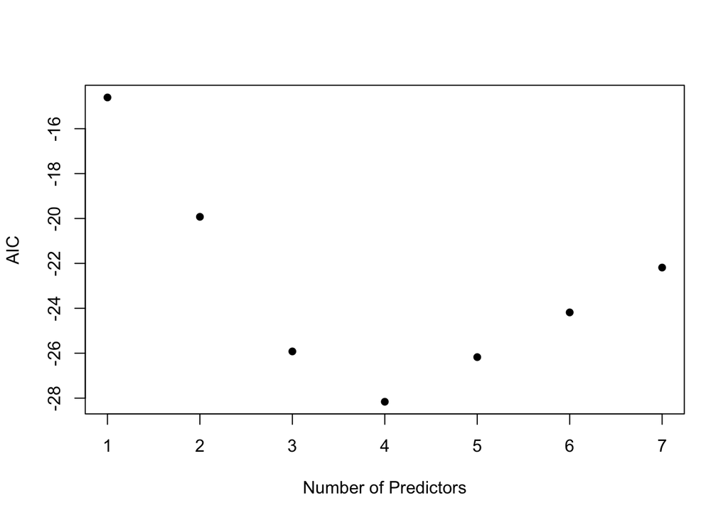

```r
n <- nrow(statedata) # number observation n = 50
rss <- best_sum$rss # rss calculated for each model

# compute AIC using the formula
AIC <- n * log(rss/n) + (2:8)*2  # going from p=2 to p=8 regressors

plot(AIC ~ I(1:7),
     ylab = "AIC",
     xlab = "Number of Predictors",
     pch = 16)
```

## Question 6

Interpret the output from the AIC plot above. What is the best model according to this metric?

### Solution to Question 6

# Bayesian Information Criterion (BIC)

The Bayesian Information Criterion (BIC) is another criteria that is often and is almost the same as AIC.

$$BIC(\mathcal{M})=-2L(\mathcal{M})+\log{(n)}p_{\mathcal{M}}.$$

- As $\mbox{RSS}_{\mathcal{M}}$ gets smaller (better fit), $n\log{(\mbox{RSS}_{\mathcal{M}}/n)}$ gets smaller (becomes more negative).
  - Adding more predictors (that are not collinear) will improve the fit.
- As $p_{\mathcal{M}}$ gets larger, the second term $\log{(n)}p_{\mathcal{M}}$ gets bigger.
  - The more parameters, the larger the penalty.
  - **The penalty for more predictors is magnified by the factor $\log{(n)}$**.
- BIC has assigns a harsher penalty for adding more regressors.
- **We choose the model the minimizes the BIC**.

```r
(BIC <- best_sum$bic)  # bic from summary
```

```
[1] -39.22051 -42.62472 -46.70678 -47.03640 -43.13738 -39.23342 -35.32373
```

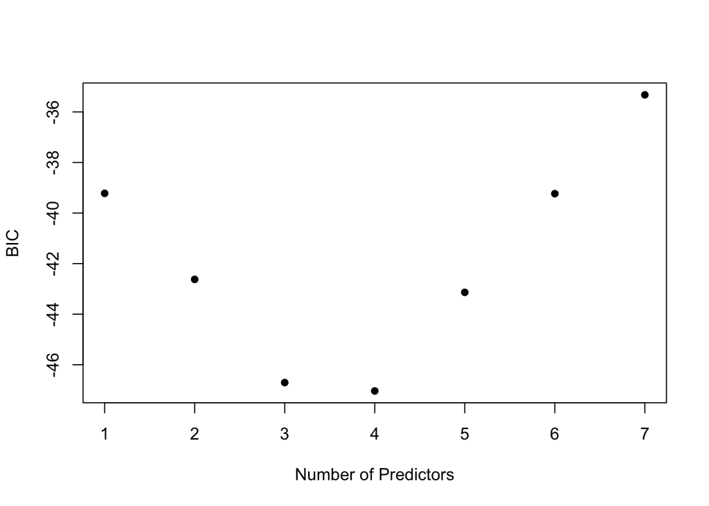

```r
#(BIC2 <- n * log(rss/n) + log(n)* (2:8))  # Using the formula
#BIC - BIC2 # The two differ by a constant
plot(BIC ~ I(1:7), ylab = "BIC", xlab = "Number of Predictors", pch = 16)
```

## Question 7

Interpret the output from the BIC plot above. What is the best model according to this metric?

### Solution to Question 7

## The `subsets` Function from `car` Package

The `car` package has a `subsets` function that generates nice, labeled BIC plots generated from the `regsubsets` function.

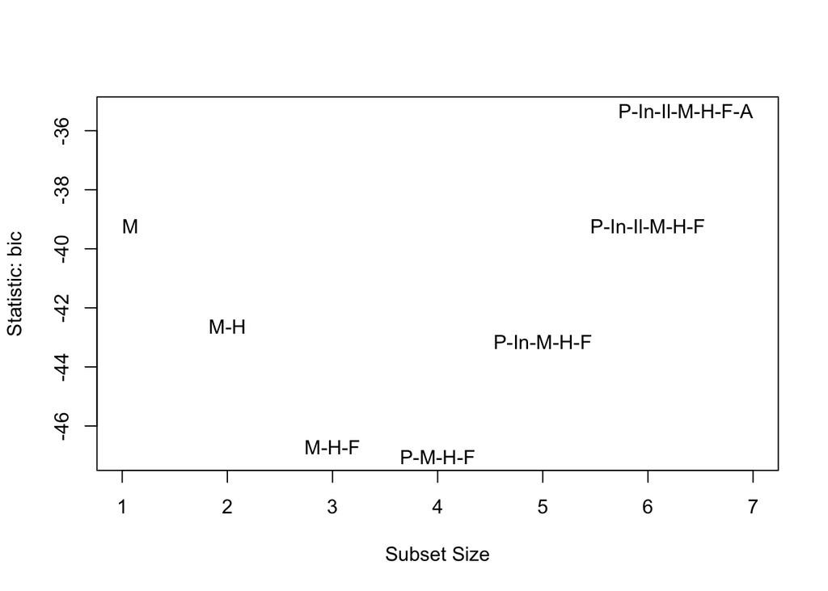

```
           Abbreviation
Population            P
Income               In
Illiteracy           Il
Murder                M
HS.Grad               H
Frost                 F
Area                  A
```

```r
#library(car)
# stat can be “bic”, “cp”, “adjr2”, “rsq”, “rss”
subsets(best, statistic = "bic", legend = FALSE)
```

# Summary of AIC and BIC

Both AIC and BIC are criteria that balance fit and complexity.

$$\mbox{AIC}(\mathcal{M})= n\log{(\mbox{RSS}_{\mathcal{M}}/n)} +2p_{\mathcal{M}} +c.$$

$$\mbox{BIC}(\mathcal{M})= n\log{(\mbox{RSS}_{\mathcal{M}}/n)} + \log{(n)} p_{\mathcal{M}} +c.$$

- As $RSS$ goes down, both AIC and BIC goes down.
- As $p_{\mathcal{M}}$ goes up, there is a penalty for making things more complicated.
  - BIC assigns a bigger penalty for adding more predictors, so it will slightly favor simple models to complex models (compared to AIC).
- The constant $c$ is the same for all models created from the same data, so it can be ignored.

We have used the following functions:

- `step()` from `base` R to perform forward, backward, stepwise methods for minimizing AIC.
- `regsubsets()` from the `leaps` package picks a subset of all predictors that minimizes RSS.
- `subsets()` from the `car` package creates plots of `regsubsets` objects.

# Adjusted $R^2$

The **adjusted $R^2$** is another criterion that penalizes for the number of parameters in the model. Adjusted $R^2$, ${\color{blue}{R_{a}^2}}$ is a better criterion for assessing model fit than $R^2$.

For model $\mathcal{M}$ with $p_{\mathcal{M}}$ regression coefficients,

$$R_a^2=1- \frac{\mbox{RSS}_\mathcal{M}/(n-p_\mathcal{M})}{\mbox{TSS}/(n-1)} = 1 - \left(\frac{n-1}{n-p_{\mathcal{M}}} \right) \left( 1-R^2 \right) = 1 - \frac{\hat{\sigma}^2_{\mathcal{M}}}{\hat{\sigma}^2_{\rm null}}.$$

**Adding a regressor to a model only increases $R_a^2$ if the regressor has some predictive value.**

- Minimizing the variance of the prediction error amounts to minimizing $\hat{\sigma}^2_{\mathcal{M}}$.
- The smaller that $\hat{\sigma}^2_{\mathcal{M}}$ becomes the larger $R^2_a$ becomes.
- **We favor models that produce larger $R_a^2$.**

## Computing the Adjusted $R^2$

```r
#summary(lmod)  # gives R^2 for full model
(adjr <- best_sum$adjr)  # extracts R_a^2 from regsubsets
```

```
[1] 0.6015893 0.6484991 0.6939230 0.7125690 0.7061129 0.6993268 0.6921823
```

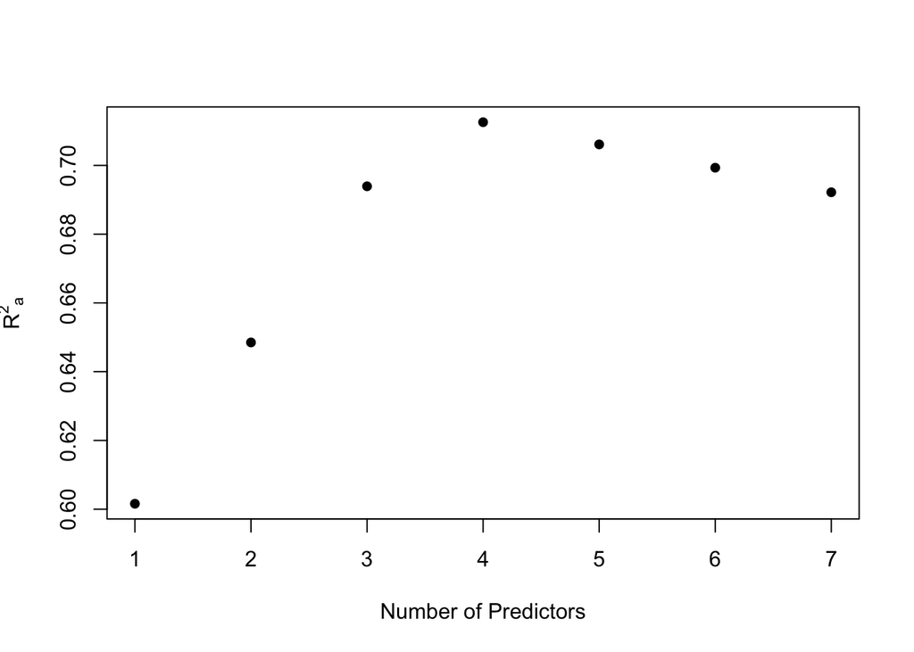

```r
p <- 1:7  # number of predictors (excluding intercept)
plot(adjr ~ p, ylab = expression({R^2}[a]),
     xlab = "Number of Predictors", pch = 16)
```

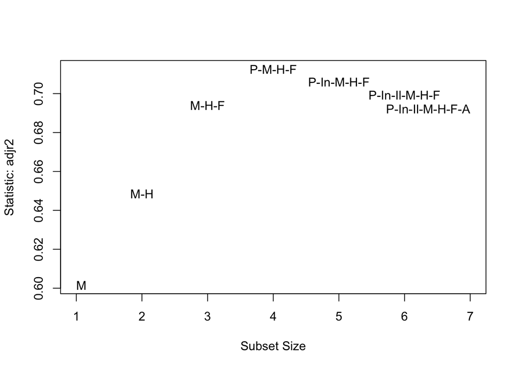

```
           Abbreviation
Population            P
Income               In
Illiteracy           Il
Murder                M
HS.Grad               H
Frost                 F
Area                  A
```

```r
subsets(best, statistic = "adjr2", legend = FALSE)
```

# Mean Square Error (MSE)

The **Mean Square Error (MSE)** of an estimator measures the average squared distance between the estimator and the parameter:

$$\mbox{MSE} (\hat{\theta}) = E \left( (\hat{\theta} - \theta)^2 \right) = \mbox{Var} (\hat{\theta}) + \left( \mbox{Bias}(\hat{\theta})\right)^2$$

- MSE is a criterion the combines bias and efficiency.
- If two estimators are unbiased, one is more efficient than the other if and only if it has a smaller MSE.
- We favor models with smaller mean squared error, but the search algorithm is very important, otherwise you just use the model with the most regressors.

## Root Mean Squared Error

The **RMSE (root mean squared error)** is simply the square root of the MSE, and is sometimes used in place of the MSE.

- The RMSE or MSE will produce identical variable selection results since they are 1-1 transformations of each other.

# Mallow’s $C_p$ Statistic

**Mallow’s $C_p$ statistic** is a criterion designed to quantify the predictive usefulness of a model. Mallow’s $C_p$ statistic is used to estimate the average **mean square error** of the prediction,

$$\frac{1}{\sigma^2} \sum_i MSE(\hat{y}_i) = \frac{1}{\sigma^2} \sum_iE\big( (\hat{y}_i - E(y_i))^2 \big)$$

The average of the mean square errors can be approximated by Mallow’s $C_p$ Statistic:

$$C_{p_{\mathcal{M}}} = \frac{\mbox{RSS}_{\mathcal{M}}}{\hat{\sigma}^2} + 2p_{\mathcal{M}} - n$$
.

- For the model with all regressors (model $\Omega$ with $p_{\Omega}$ regression coefficients), we have $C_{p_{\Omega}}=p_{\Omega}$
- If a model with $p_{\mathcal{M}}$ regression coefficients fits the data well and has little or no bias, then $E(C_{p_{\mathcal{M}}}) \approx p_{\mathcal{M}}$.
  - A model with a biased fit will have $C_{p_{\mathcal{M}}}$ much larger than $p_{\mathcal{M}}$.
  - Models with $C_{p_{\mathcal{M}}}$ less than $p_{\mathcal{M}}$ do not show evidence of bias.
- It is common to plot $C_{p_{\mathcal{M}}}$ versus $p_{\mathcal{M}}$ and compare this to $45^{\circ}$ line $C_{p_{\mathcal{M}}}= p_{\mathcal{M}}$ .
- **We favor models with small $p_{\mathcal{M}}$ and $C_{p_{\mathcal{M}}}$ close to $p_\mathcal{M}$.**

## Computing Mallow’s $C_p$ Statistic

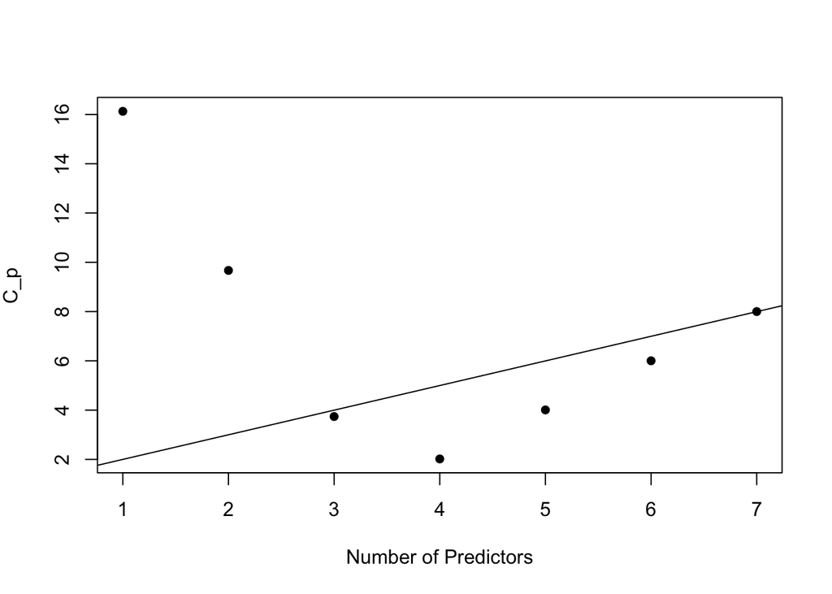

```r
cp <- best_sum$cp # Display the C_p for each value of p
plot(cp ~ p, ylab = expression({C_p}),
     xlab = "Number of Predictors", pch = 16)
abline(1,1) # plots line y=x + 1 (add 1 since p does not include intercept)
```

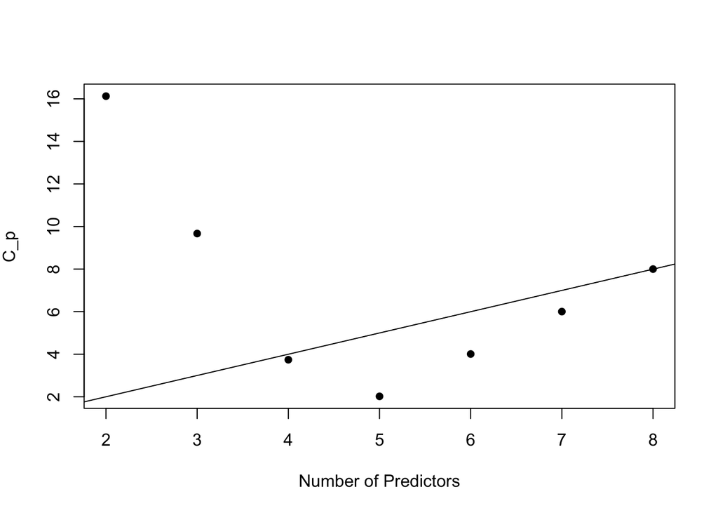

```r
# another way to plot
# now x-axis includes intercept in count for p
cp <- best_sum$cp # Display the C_p for each value of p
plot(cp ~ I(2:8), ylab = expression({C_p}), # include intercept
     xlab = "Number of Predictors", pch = 16)
abline(0,1) # plots line y= p  (since p now includes intercept)
```

```r
subsets(best, statistic = "cp", legend = FALSE)
```

```
           Abbreviation
Population            P
Income               In
Illiteracy           Il
Murder                M
HS.Grad               H
Frost                 F
Area                  A
```

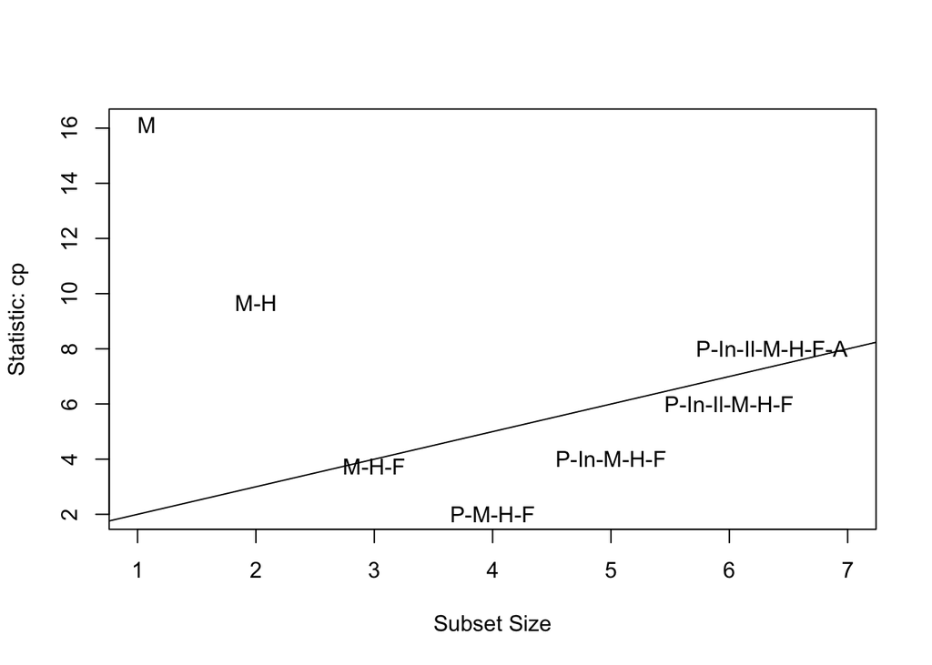

```r
abline(1,1)  # plots line y=x + 1 (add 1 since p does not include intercept)
```

## Question 8

Interpret the output from the $C_p$ plot above. What is the best model according to this metric?

### Solution to Question 8

# Cross-validation

- Well, we just used all of our sample data to construct this model.
- We need to see how well our data does with new data (not used in construction of the model).
- How can we see how good our model works?

**Cross-validation** breaks the data into a **training dataset** and a **test dataset** to get a more accurate assessment of the predictive accuracy of a model.

1. A model is fit to the training dataset.
2. The fitted model is used to predict the responses of the test dataset.
3. An error criterion (e.g, the MSE) is calculated for the test dataset.

**When using cross-validation as your selection criterion, we prefer the model that produces the lowest MSE (or RMSE).**

## Methods For Splitting the Data

There are many variations of how to choose the training and testing datasets for crossvalidation.

### Leave-One Out Crossvalidation

**Leave-one-out crossvalidation** uses each observation (individually) as a test data set, using the other $n-1$ observations as the training data.

#### Should We Inlcude Population?

```r
ersq <- numeric(n)  # store the squared error

for (i in 1:n){
  train.ds <- statedata[-i, ]
  test.ds <- statedata[i, ]
  tmod <- lm(Life.Exp ~ Population + Murder + HS.Grad + Frost, data = train.ds)
  predy <- predict(tmod, new = test.ds)
  y <- test.ds[1,4]
  ersq[i] <- (predy - y)^2
}

(tmse <- sum(ersq))
```

```
[1] 29.64823
```

```r
ersq <- numeric(n)

for (i in 1:n){
  train.ds <- statedata[-i, ]
  test.ds <- statedata[i, ]
  tmod <- lm(Life.Exp ~ Murder + HS.Grad + Frost, data = train.ds)
  predy <- predict(tmod, new = test.ds)
  y <- test.ds[1,4]
  ersq[i] <- (predy - y)^2
}

(tmse <- sum(ersq))
```

```
[1] 31.19675
```

### $k$-Fold Crossvalidation

**$k$-fold crossvalidation** breaks the data into $k$ unique sets.

- For each set, the other $k-1$ sets are used as training data, and then the fitted model is used to predict the responses for the $k$th testing set.
- We must fit $k$ models to determine the mean squared error.

## Example of $k$-fold Crossvalidation

Let’s comparison the full model to model with `Population`, `Murder`, `HS.Grad`, and `Frost` predictors using the RMSE criterion and both 10-fold crossvalidation and leave-one-out crossvalidation.

The `caret` package (short for Classification And REgression Training) contains functions to streamline the model training process for regression and classification problems.

```r
# you may need to install caret before running code
#library(caret)

# define training/test (control) data
cv_10fold <- trainControl(method="cv", number = 10) # 10-fold crossvalidation train/test data

# Set up full and our model with 4 regressors
f1 <- Life.Exp ~ . # formula for full model
f2 <- Life.Exp~Population + Murder + HS.Grad + Frost

# Using training data to construct each model
modela <- train(f1, data = statedata, trControl=cv_10fold, method = "lm") #full
modelb <- train(f2, data = statedata, trControl=cv_10fold, method = "lm") #with 4 reg
print(modela) # full, 10-fold
```

```
Linear Regression

50 samples
 7 predictor

No pre-processing
Resampling: Cross-Validated (10 fold)
Summary of sample sizes: 45, 44, 46, 44, 44, 46, ...
Resampling results:

  RMSE       Rsquared   MAE
  0.8456143  0.7068443  0.6853861

Tuning parameter 'intercept' was held constant at a value of TRUE
```

```r
print(modelb) # reduced, 10-fold
```

```
Linear Regression

50 samples
 4 predictor

No pre-processing
Resampling: Cross-Validated (10 fold)
Summary of sample sizes: 44, 45, 45, 44, 43, 45, ...
Resampling results:

  RMSE       Rsquared   MAE
  0.7516807  0.7277653  0.6436334

Tuning parameter 'intercept' was held constant at a value of TRUE
```

```r
# leave-one-out crossvalidation train/test data
cv_loo <- trainControl(method="LOOCV")

modelfull <- train(f1, data = statedata, trControl=cv_loo, method = "lm") #full
modelred <- train(f2, data = statedata, trControl=cv_loo, method = "lm") #with 4 reg
print(modelfull) # full, leave one out
```

```
Linear Regression

50 samples
 7 predictor

No pre-processing
Resampling: Leave-One-Out Cross-Validation
Summary of sample sizes: 49, 49, 49, 49, 49, 49, ...
Resampling results:

  RMSE       Rsquared   MAE
  0.9090885  0.5469535  0.7196334

Tuning parameter 'intercept' was held constant at a value of TRUE
```

```r
print(modelred) # reduced, leave one out
```

```
Linear Regression

50 samples
 4 predictor

No pre-processing
Resampling: Leave-One-Out Cross-Validation
Summary of sample sizes: 49, 49, 49, 49, 49, 49, ...
Resampling results:

  RMSE      Rsquared   MAE
  0.770042  0.6657615  0.6377097

Tuning parameter 'intercept' was held constant at a value of TRUE
```

# There’s Still More to Consider!

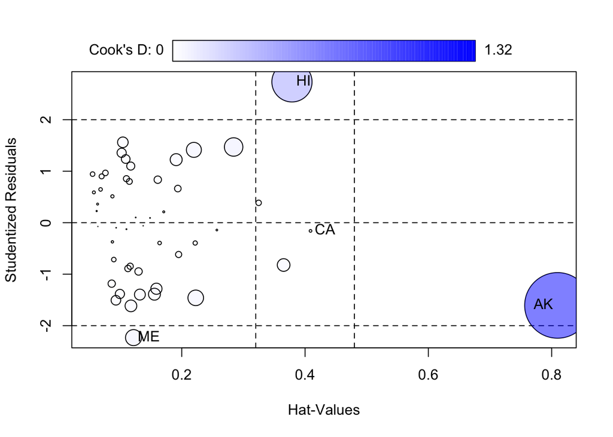

```
      StudRes       Hat       CookD
AK -1.6061632 0.8095223 1.320803928
CA -0.1590567 0.4088569 0.002239186
HI  2.7352416 0.3787617 0.493948906
ME -2.2322062 0.1218190 0.078915835
```

```r
#library(car)  # needed but we already loaded
influencePlot(lmod)
```

Let’s remove Alaska since it is a high leverage point. Then identify best subset using $R^2_a$ as our search criterion.

```r
best2 <- regsubsets(Life.Exp ~., data = statedata, subset = (state.abb != "AK"))
best_sum2 <- summary(best2)
best_sum2$which[which.max(best_sum2$adjr), ]
```

```
(Intercept)  Population      Income  Illiteracy      Murder     HS.Grad
       TRUE        TRUE       FALSE       FALSE        TRUE        TRUE
      Frost        Area
       TRUE        TRUE
```

# Summary

There are other mechanisms for choosing the training and test datasets, but these are the most common.

- **When using cross-validation as your selection criterion, we prefer the model that produces the lowest MSE or RMSE.**
- You typically don’t do an exhaustive search or stepwise selection search.
- You often use one of the other selection criteria/search strategies to narrow down the possible models to a few final candidate models and then use cross-validation to make a final decision.
- Iteration and experimentation are essential to finding better models BUT be very careful not to overtrain your model to the sample data!

# Practice

For the `teengamb` data in the `faraway` package, use the methods learned in this chapter to identify the “best” models.

```r
data(teengamb, package = "faraway")  # load data
summary(teengamb)
```

```
      sex             status          income           verbal
 Min.   :0.0000   Min.   :18.00   Min.   : 0.600   Min.   : 1.00
 1st Qu.:0.0000   1st Qu.:28.00   1st Qu.: 2.000   1st Qu.: 6.00
 Median :0.0000   Median :43.00   Median : 3.250   Median : 7.00
 Mean   :0.4043   Mean   :45.23   Mean   : 4.642   Mean   : 6.66
 3rd Qu.:1.0000   3rd Qu.:61.50   3rd Qu.: 6.210   3rd Qu.: 8.00
 Max.   :1.0000   Max.   :75.00   Max.   :15.000   Max.   :10.00
     gamble
 Min.   :  0.0
 1st Qu.:  1.1
 Median :  6.0
 Mean   : 19.3
 3rd Qu.: 19.4
 Max.   :156.0
```

```r
# fit full model
gamb_lmod <- lm(gamble ~ ., data = teengamb)
summary(gamb_lmod) # determine least significant predictor
```

```
Call:
lm(formula = gamble ~ ., data = teengamb)

Residuals:
    Min      1Q  Median      3Q     Max
-51.082 -11.320  -1.451   9.452  94.252

Coefficients:
             Estimate Std. Error t value Pr(>|t|)
(Intercept)  22.55565   17.19680   1.312   0.1968
sex         -22.11833    8.21111  -2.694   0.0101 *
status        0.05223    0.28111   0.186   0.8535
income        4.96198    1.02539   4.839 1.79e-05 ***
verbal       -2.95949    2.17215  -1.362   0.1803
---
Signif. codes:  0 '***' 0.001 '**' 0.01 '*' 0.05 '.' 0.1 ' ' 1

Residual standard error: 22.69 on 42 degrees of freedom
Multiple R-squared:  0.5267,    Adjusted R-squared:  0.4816
F-statistic: 11.69 on 4 and 42 DF,  p-value: 1.815e-06
```

```r
# Values we'll need
n <- nobs(gamb_lmod)  # number of observations
p <- 2:5  # possible number of regressors
```

# Appendix: Maximum Likelihood Estimates (MLE)

The **likelihood function** $L(\theta)= L( \theta \mid x_1, x_2, \ldots x_n)$ gives the likelihood of the parameter $\theta$ given the observed data. A **maximum likelihood estimate (MLE)**, $\mathbf{\hat{\theta}_{\rm MLE}}$,}} is a value of $\theta$ that maximizes the likelihood function.

**MLE is a process for finding the best parameter(s) for a model based on a given dataset**

Let $f(x; \theta)$ denote the pdf of a random variable $X$ with associated parameter $\theta$. Suppose $X_1, X_2, \ldots , X_n$ are random samples from this distribution, and $x_1, x_2, \ldots , x_n$ are the corresponding observed values.

$$L(\theta \mid x_1, x_2, \ldots , x_n) = f(x_1; \theta) f(x_2; \theta) \ldots f(x_n; \theta) = \prod_{i=1}^n f(x_i; \theta).$$

## Example: Finding and MLE

Find the MLE for $\lambda$ where $x_1, x_2, \ldots , x_n$ comes from $X \sim \mbox{Exp}(\lambda)$ with $f(x; \lambda) = \lambda e^{-\lambda x}$.

1. Find a formula for the likelihood function.

$$L(\lambda \mid x_1, x_2, \ldots , x_n) = \left(\lambda e^{-\lambda x_1} \right)\left(\lambda e^{-\lambda x_2} \right) \ldots \left(\lambda e^{-\lambda x_n} \right) = \lambda^n e^{-\lambda \sum_{i=1}^n x_i} .$$

2. Optimize the likelihood function. Find the value of $\lambda$ that makes the observed data most likely to occur.

$$\frac{d}{d \lambda} \left( \lambda^n e^{-\lambda \sum_{i=1}^n x_i} \right)$$

Often this is really messy to solve. Taking the natural log of both sides often simplifies the calculation.

The **log-likelihood**function is $y = \ln{L(\theta \mid x_1, x_2, \ldots , x_n) }$ (often written with $\log$ though we mean $\ln$). - Since the natural log is an increasing function, the value of $\theta$ that maximizes (or minimizes) $L(\theta \mid x_1, x_2, \ldots , x_n)$ is the same value of $\theta$ that maximizes (or minimizes) $y = \ln{L(\theta \mid x_1, x_2, \ldots , x_n) }$.

$$y = \ln{\left(\lambda^n e^{-\lambda \sum_{i=1}^n x_i}\right)} = n \ln{(\lambda)}- \lambda \sum_{i=1}^n x_i$$
It actually is easier to optimize the log-likelihood function in this case:

$$\begin{aligned}
\frac{d}{d \lambda} \ln{\left(\lambda^n e^{-\lambda \sum_{i=1}^n x_i}\right)} &= \frac{d}{d \lambda} \left( n \ln{(\lambda)}- \lambda \sum_{i=1}^n x_i \right) \\
&= \frac{n}{\lambda} - \sum_{i=1}^n x_i
\end{aligned}$$